# Задание 7.1.

На основании учебных данных о стоимости жилья в г. Бостоне (sklearn.datasets.load_boston) необходимо предсказать стоимость дома со следующими характеристиками: CRIM=0.05; ZN=0; INDUS=11.9; CHAS=0; NOX=0.6; RM=6.1; AGE=80; DIS=2.5; RAD=1; TAX=3; PTRATIO=21; B=397; LSTAT=7.98.

```python
# Загружаем набор данных (цены на жилье в Бостоне)
from sklearn.datasets import load_boston
import pandas as pd
X, y = load_boston(return_X_y=True)

boston_data = load_boston()
df_boston = pd.DataFrame(boston_data.data,columns=boston_data.feature_names)
df_boston['target'] = pd.Series(boston_data.target)

from sklearn.linear_model import LogisticRegression
from sklearn.neighbors import KNeighborsRegressor
#построение и обучение модели
regr = KNeighborsRegressor()
regr.fit(boston_data.data, boston_data.target)
boston_data.data
#формирование прогноза
X_pred = pd.DataFrame([[0.05, 0, 11.9, 0, 0.6, 6.1, 80, 2.5, 1, 3, 21, 397, 7.98]])
y_pred = regr.predict(X_pred)
print(y_pred)
```

```
[20.6]
```

# Задание 7.2

На основании набора данных, полученного при решении зада-ния 5, приведенного в предыдущей теме, проведите исследование и сравнительные эксперименты для следующих методов построения моделей регрессии (по вариантам):

3) риджевой регрессии со встроенной перекрестной проверкой;

При проведении экспериментов использовать различные допу-стимые комбинации параметры методов. Сделайте выводы.

# Задание 6.5

```
w0 = 0.7209481325518342
w1 = 0.0005284018683105916
y=0.7209481325518342+0.0005284018683105916x
Среднеквадратическое отклонение: 0.410
Коэффициент детерминации (R-квадрат): -0.844
или (1-идеальное предсказание): -0.844
```

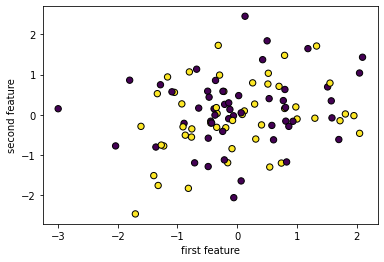

```python
from sklearn.datasets import make_classification
from sklearn.model_selection import train_test_split
from sklearn.metrics import mean_squared_error, r2_score
import matplotlib.pyplot as plt
from sklearn.linear_model import Ridge
import numpy as np
# получение данных
X, y = make_classification(n_features=600, n_redundant=12, n_informative=5,
                             n_clusters_per_class=3)

#ФУНКЦИЯ ДЛЯ ПОСТРОЕНИЯ МОДЕЛЕЙ РЕГРЕССИИ РАЗНЫМИ МЕТОДАМИ

# разбивка: обучение - контроль
train_size = 88
test_size = 12
X_train = X[:-train_size]
X_test = X[-test_size:]
y_train= y[:-train_size]
y_test = y[-test_size:]
#построение и обучение модели
regr = Ridge()
regr.fit(X_train, y_train)
#определение и вывод параметров построенной модели
w0 = str(regr.intercept_)
w1 = str(regr.coef_[0])
y_func = 'y='+ w0 + '+' + str(w1) + 'x'
print('w0 = '+w0)
print('w1 = '+w1)
print(y_func)

#формирование прогноза
y_pred = regr.predict(X_test)

#оценка прогноза
print('Среднеквадратическое отклонение: %.3f'
         % mean_squared_error(y_test, y_pred))
print('Коэффициент детерминации (R-квадрат): %.3f'
         % r2_score(y_test, y_pred))
print('или (1-идеальное предсказание): %.3f'
         % regr.score(X_test, y_test))
plt.xlabel("first feature")
plt.ylabel("second feature")
plt.scatter(X[:, 0], X[:, 1], marker='o', c=y, s=40, edgecolor='k')
```

# Задание 7.3

На основании данных о производстве конфет в США с января 1972 по настоящий момент необходимо спрогнозировать индустри-альный продуктовый индекс (IPG3113N – универсальный индекс уровня производства, который измеряется как % от уровня производ-ства 2012 года).

Горизонт прогнозирования выбран: временной интервал в 24 месяца.

Источник данных: https://fred.stlouisfed.org/series/IPG3113N

Необходимо:

1) загрузить набор данных;

2) провести исследование данных;

3) выполнить предварительную обработку данных (при необхо-димости);

4) выбрать метод построения модели регрессии (решение обос-новать);

5) выбрать метрику оценки качества модели (решение обосно-вать);

6) осуществить обучение и тестирование модели регрессии с ис-пользованием различных комбинаций её параметров;

7) оценить качество различных по параметрам вариантов модели по выбранной метрике;

8) спрогнозировать целевой показатель на основании варианта модели с лучшим значением метрики на заданном горизонте.

```python
from sklearn.preprocessing import LabelEncoder, OneHotEncoder
from sklearn.metrics import classification_report, confusion_matrix
from sklearn.linear_model import Ridge
#'IPG3113N'
import pandas as pd

df=pd.read_csv(
    'C:/Users/logistics/Downloads/IPG3113N.csv',
    sep=',',
    decimal=","
)
#создание модели и ее тренировка
X=df['DATE']
y=df['IPG3113N']
print("Исходные данные: ", '\n', y)
X = X.values.reshape(-1,1)
labelencoder_x = LabelEncoder()
X = labelencoder_x.fit_transform(X)
X = X.reshape(-1,1)
X_train, X_test, y_train, y_test = train_test_split(X, y, random_state=0, train_size=0.88)

maxScoreAlpha=0

maxScore=-1
maxScoreW0=0
maxScoreW1=0
#построение и обучение модели
#формирование и оценка прогноза
#при разных значениях коэффициента регуляризации
for k_alpha in np.arange(0.25,   5,   0.25):
    model = Ridge(alpha=k_alpha)
    model.fit(X_train, y_train)
    y_pred = model.predict(X_test)
    surrentScore=model.score(X_test, y_test)
    if maxScore<= surrentScore:
        maxScoreAlpha = k_alpha
        maxScore=surrentScore
        maxScoreW0=str(model.intercept_)
        maxScoreW1=str(model.coef_[0])

#вывод параметров оптимальной модели
print("Параметры оптимальной модели: ", '\n')
y_func = 'y='+ maxScoreW0 + ('+' if maxScoreW0>'0' else '') + str(maxScoreW1) + 'x'
print('w0 = '+maxScoreW0)
print('w1 = '+maxScoreW1)
print(y_func)

#прогноз
result = 0
print("Прогноз на 24 месяца: ")
for k_alpha in range(592,   616):
    result = np.float64(maxScoreW0) + np.float64(maxScoreW1) * k_alpha
    print(k_alpha,":", result , '\n')
```

[output not shown]

[output cut: 11 more lines]

```
608 : 121.4498944627702

609 : 121.51112726128024

610 : 121.57236005979027

611 : 121.63359285830029

612 : 121.69482565681032

613 : 121.75605845532036

614 : 121.81729125383038

615 : 121.87852405234042
```

# Задание 7.4.

```python
from sklearn.preprocessing import LabelEncoder, OneHotEncoder
from sklearn.metrics import classification_report, confusion_matrix
#'IPG3113N'
import pandas as pd

df=pd.read_csv(
    'C:/Users/logistics/Downloads/ECOMPCTSA.csv',
    sep=',',
    decimal=","
)
#создание модели и ее тренировка
X=df['DATE']

y=df['ECOMPCTSA']
print("Исходные данные: ", '\n', y)
X = X.values.reshape(-1,1)
labelencoder_x = LabelEncoder()
X = labelencoder_x.fit_transform(X)
X = X.reshape(-1,1)
X_train, X_test, y_train, y_test = train_test_split(X, y, random_state=0, train_size=0.88)


maxScoreAlpha=0

maxScore=-1
maxScoreW0=0
maxScoreW1=0
#построение и обучение модели
#формирование и оценка прогноза
#при разных значениях коэффициента регуляризации
for k_alpha in np.arange(0.25,   5,   0.25):
    model = Ridge(alpha=k_alpha)
    model.fit(X_train, y_train)
    y_pred = model.predict(X_test)
    surrentScore=model.score(X_test, y_test)
    if maxScore<= surrentScore:
        maxScoreAlpha = k_alpha
        maxScore=surrentScore
        maxScoreW0=str(model.intercept_)
        maxScoreW1=str(model.coef_[0])

#вывод параметров оптимальной модели
print("Параметры оптимальной модели: ", '\n')
y_func = 'y='+ maxScoreW0 + ('+' if maxScoreW0>'0' else '') + str(maxScoreW1) + 'x'
print('w0 = '+maxScoreW0)
print('w1 = '+maxScoreW1)
print(y_func)

#прогноз
result = 0
print("Прогноз на 24 месяца: ")
for k_alpha in range(86,   110):
    result = np.float64(maxScoreW0) + np.float64(maxScoreW1) * k_alpha
    print(k_alpha,":", result , '\n')
```

```
Исходные данные:
 0      0.6
1      0.8
2      0.9
3      1.0
4      1.0
      ...
81    11.4
82    15.7
83    13.8
84    13.6
85    13.6
Name: ECOMPCTSA, Length: 86, dtype: object
Параметры оптимальной модели:

w0 = -0.5344880502551401
w1 = 0.1348788155285914
y=-0.53448805025514010.1348788155285914x
Прогноз на 24 месяца:
86 : 11.065090085203721

87 : 11.199968900732312

88 : 11.334847716260903

89 : 11.469726531789496

90 : 11.604605347318087

91 : 11.739484162846678

92 : 11.874362978375268

93 : 12.009241793903861

94 : 12.144120609432452

95 : 12.278999424961043

96 : 12.413878240489636
```

[output cut: 11 more lines]

```
102 : 13.223151133661183

103 : 13.358029949189774

104 : 13.492908764718367

105 : 13.627787580246958

106 : 13.762666395775549

107 : 13.89754521130414

108 : 14.032424026832732

109 : 14.167302842361323
```

# Задание 7.5.

На основании данных о рынке недвижимости США спрогнози-ровать среднюю стоимость новых домов. Горизонт прогнозирования выбран: временной интервал в 24 месяца Источник данных: https://fred.stlouisfed.org/series/MSPUS Необходимо: 1) загрузить набор данных; 2) провести исследование данных; 3) выполнить предварительную обработку данных (при необхо-димости); 4) выбрать несколько методов построения модели регрессии (решение обосновать); 5) выбрать метрику оценки качества модели (решение обосно-вать); 6) осуществить обучение и тестирование моделей регрессии с использованием различных комбинаций их параметров; 7) оценить качество различных по параметрам вариантов моде-лей по выбранной метрике; 8) спрогнозировать целевой показатель на основании варианта модели с лучшим значением метрики на заданном горизонте.

```python
from sklearn.preprocessing import LabelEncoder, OneHotEncoder
from sklearn.metrics import classification_report, confusion_matrix
#'IPG3113N'
import pandas as pd

df=pd.read_csv(
    'C:/Users/logistics/Downloads/MSPUS.csv',
    sep=',',
    decimal=","
)
#создание модели и ее тренировка
X=df['DATE']

y=df['MSPUS']
print("Исходные данные: ", '\n', y)
X = X.values.reshape(-1,1)
labelencoder_x = LabelEncoder()
X = labelencoder_x.fit_transform(X)
X = X.reshape(-1,1)
X_train, X_test, y_train, y_test = train_test_split(X, y, random_state=0, train_size=0.88)



maxScoreAlpha=0

maxScore=-1
maxScoreW0=0
maxScoreW1=0
#построение и обучение модели
#формирование и оценка прогноза
#при разных значениях коэффициента регуляризации
for k_alpha in np.arange(0.25,   5,   0.25):
    model = Ridge(alpha=k_alpha)
    model.fit(X_train, y_train)
    y_pred = model.predict(X_test)
    surrentScore=model.score(X_test, y_test)
    if maxScore<= surrentScore:
        maxScoreAlpha = k_alpha
        maxScore=surrentScore
        maxScoreW0=str(model.intercept_)
        maxScoreW1=str(model.coef_[0])

#вывод параметров оптимальной модели
print("Параметры оптимальной модели: ", '\n')
y_func = 'y='+ maxScoreW0 + ('+' if maxScoreW0>'0' else '') + str(maxScoreW1) + 'x'
print('w0 = '+maxScoreW0)
print('w1 = '+maxScoreW1)
print(y_func)

#прогноз
result = 0
print("Прогноз на 24 месяца: ")
for k_alpha in range(233,   257):
    result = np.float64(maxScoreW0) + np.float64(maxScoreW1) * k_alpha
    print(k_alpha,":", result , '\n')
```

```
Исходные данные:
 0         17800
1         18000
2         17900
3         18500
4         18500
         ...
228    329000.0
229    322600.0
230    337500.0
231    358700.0
232    347500.0
Name: MSPUS, Length: 233, dtype: object
Параметры оптимальной модели:

w0 = -24499.101012547704
w1 = 1411.301926041014
y=-24499.1010125477041411.301926041014x
Прогноз на 24 месяца:
233 : 304334.2477550085

234 : 305745.54968104954

235 : 307156.85160709056

236 : 308568.1535331316

237 : 309979.4554591726

238 : 311390.7573852136

239 : 312802.05931125465

240 : 314213.36123729567

241 : 315624.6631633367

242 : 317035.9650893777

243 : 318447.26701541874
```

[output cut: 11 more lines]

```
249 : 326915.07857166475

250 : 328326.3804977058

251 : 329737.6824237468

252 : 331148.9843497878

253 : 332560.28627582884

254 : 333971.58820186986

255 : 335382.8901279109

256 : 336794.1920539519
```

# Задание 7.6.

На основании данных о первичном рынке недвижимости любо-го региона Российской Федерации спрогнозировать среднюю стои-мость 1 м2 общей площади квартир. Горизонт прогнозирования выбран: временной интервал в 24 месяца Источник данных: https://showdata.gks.ru/report/277332/? Необходимо: 1) загрузить набор данных; 2) провести исследование данных; 3) выполнить предварительную обработку данных (при необхо-димости); 4) выбрать несколько методов построения модели регрессии (решение обосновать); 5) выбрать метрику оценки качества модели (решение обосно-вать); 6) осуществить обучение и тестирование моделей регрессии с использованием различных комбинаций их параметров; 7) оценить качество различных по параметрам вариантов моде-лей по выбранной метрике; 8) спрогнозировать целевой показатель на основании варианта модели с лучшим значением метрики на заданном горизонте.

```python
price_vladimir = pd.read_excel('C:/Users/logistics/Downloads/11511200200010200001_Средняя_цена_1_кв_м__общей_площади_квартир_на_рынке_жилья_(до_2020_г__включител.xlsx')

#создание модели и ее тренировка
X = np.arange(8).reshape(-1, 1)

y= price_vladimir.iloc[3].values

y = np.delete(y, (0,1))
print("Исходные данные: ", '\n', y)
X_train, X_test, y_train, y_test = train_test_split(X, y, random_state=0, train_size=0.60)




maxScoreAlpha=0

maxScore=-1
maxScoreW0=0
maxScoreW1=0
#построение и обучение модели
#формирование и оценка прогноза
#при разных значениях коэффициента регуляризации
for k_alpha in np.arange(0.25,   2,   0.25):
    model = Ridge(alpha=k_alpha)

    model.fit(X_train, y_train)
    y_pred = model.predict(X_test)

    surrentScore=model.score(X_test, y_test)
    if maxScore<= surrentScore:
        maxScoreAlpha = k_alpha
        maxScore=surrentScore
        maxScoreW0=str(model.intercept_)
        maxScoreW1=str(model.coef_[0])

#вывод параметров оптимальной модели
print("Параметры оптимальной модели: ", '\n')
y_func = 'y='+ str(maxScoreW0) + ('+' if maxScoreW0>'0' else '') + str(maxScoreW1) + 'x'
print('w0 = ',maxScoreW0)
print('w1 = ',maxScoreW1)
print(y_func)

#прогноз
result = 0
print("Прогноз на 24 месяца: ")
for k_alpha in range(8,   32):
    result = np.float64(maxScoreW0) + np.float64(maxScoreW1) * k_alpha
    print(k_alpha,":", result , '\n')
```

```
Исходные данные:
 [35221.51 35185.69 35309.93 35524.33 38794.81 40300.05 41292.2 42875]
Параметры оптимальной модели:

w0 =  34569.56868421053
w1 =  963.5354385964911
y=34569.56868421053+963.5354385964911x
Прогноз на 24 месяца:
8 : 42277.85219298246

9 : 43241.387631578946

10 : 44204.92307017544

11 : 45168.45850877193

12 : 46131.99394736842

13 : 47095.52938596491

14 : 48059.0648245614

15 : 49022.600263157896

16 : 49986.135701754385

17 : 50949.671140350874

18 : 51913.20657894737

19 : 52876.74201754386

20 : 53840.27745614035

21 : 54803.81289473684

22 : 55767.34833333333

23 : 56730.883771929824

24 : 57694.419210526314

25 : 58657.9546491228

26 : 59621.4900877193

27 : 60585.02552631579

28 : 61548.56096491228

29 : 62512.09640350877

30 : 63475.63184210526

31 : 64439.16728070175
```

# Задание 7.7.

На основании данных о вторичном рынке недвижимости любо-го региона (или города) Российской Федерации предсказать стои-мость самостоятельно выбранного объекта недвижимости (квартиры, загородного дома, земли). Источник данных: любая база данных объявлений о продажи объектов недвижимости, размещенная в сети Интернет. Необходимо: 1) сформировать набор данных на основании любой базы дан-ных объявлений о продажи объектов недвижимости, размещенной в сети Интернет; 2) провести исследование данных; 3) выполнить предварительную обработку данных (особое вни-мание уделить наличию дубликатов, неполным сведениям и неин-формативным признакам); 4) выбрать несколько методов построения модели регрессии (решение обосновать); 5) выбрать метрику оценки качества модели (решение обосно-вать); 6) осуществить обучение и тестирование моделей регрессии с использованием различных комбинаций их параметров; 7) оценить качество различных по параметрам вариантов моде-лей по выбранной метрике; 8) спрогнозировать целевой показатель на основании варианта модели с лучшим значением метрики на заданном горизонте.

```python
#источник: https://realty.yandex.ru/vladimir/kupit/kvartira/odnokomnatnaya/?mapPolygon=56.11627%2C40.27691%3B56.11579%2C40.26764%3B56.11287%2C40.26163%3B56.10884%2C40.25665%3B56.10639%2C40.25639%3B56.10491%2C40.25699%3B56.10241%2C40.26017%3B56.10073%2C40.26558%3B56.09881%2C40.2751%3B56.09781%2C40.28515%3B56.09805%2C40.28987%3B56.10011%2C40.29553%3B56.10193%2C40.29931%3B56.10486%2C40.3024%3B56.10822%2C40.30266%3B56.1109%2C40.30042%3B56.11335%2C40.29656%3B56.1156%2C40.29012%3B56.11694%2C40.28403%3B56.11762%2C40.27536%3B56.11704%2C40.27081%3B56.11555%2C40.26721
#создание модели и ее тренировка
X=np.arange(22).reshape(-1, 1)

y=pd.DataFrame([2800000, 2670000, 2150000, 2850000, 2150000, 1720000,1599999, 1820000,3250000, 2080000, 3260000, 2600000, 2678470, 1790000, 2999000, 2681910, 3380000, 1900000, 2678470, 2350000,  2260000, 2800000 ])

print("Исходные данные: ", '\n', y)
X_train, X_test, y_train, y_test = train_test_split(X, y, random_state=0, train_size=0.60)


maxScoreAlpha=0

maxScore=-1
maxScoreW0=0
maxScoreW1=0
#построение и обучение модели
#формирование и оценка прогноза
#при разных значениях коэффициента регуляризации
for k_alpha in np.arange(0.25,   2,   0.25):
    model = Ridge(alpha=k_alpha)

    model.fit(X_train, y_train)
    y_pred = model.predict(X_test)

    surrentScore=model.score(X_test, y_test)
    if maxScore<= surrentScore:
        maxScoreAlpha = k_alpha
        maxScore=surrentScore
        maxScoreW0=str(model.intercept_[0])
        maxScoreW1=str(model.coef_[0][0])

#вывод параметров оптимальной модели
print("Параметры оптимальной модели: ", '\n')
y_func = 'y='+ str(maxScoreW0) + ('+' if maxScoreW0>'0' else '') + str(maxScoreW1) + 'x'
print('w0 = ',maxScoreW0)
print('w1 = ',maxScoreW1)
print(y_func)

#прогноз
result = 0
result = np.float64(maxScoreW0) + np.float64(maxScoreW1) * 22
print("Стоимость моей квартиры :", result , '\n')
```

```
Исходные данные:
           0
0   2800000
1   2670000
2   2150000
3   2850000
4   2150000
5   1720000
6   1599999
7   1820000
8   3250000
9   2080000
10  3260000
11  2600000
12  2678470
13  1790000
14  2999000
15  2681910
16  3380000
17  1900000
18  2678470
19  2350000
20  2260000
21  2800000
Параметры оптимальной модели:

w0 =  2141170.3401329266
w1 =  23277.496300631192
y=2141170.3401329266+23277.496300631192x
Стоимость моей квартиры : 2653275.258746813
```